# Terceiro Dia - Manipulando dados e gerando gráficos

Pedro Cavalcante

20 de fevereiro de 2019

Agora vamos conhecer dois pacotes do Tidyverse, uma coleção de pacotes com uma filosofia em comum de programação simples e legível. Ele não lhe é totalmente estranha. Ontem usamos alguns pacotes desses pacotes, como `readr`, `haven` e `readxl`, todos focados em importar dados. Agora é a hora de manipula-los com o `dplyr` e gerar visualizações de alta qualidade com o `ggplot2`.

# Manipulação de dados com do `dplyr`

Você já observou que no R quando precisamos várias funções, empilhamos elas umas dentro das outras? Normalmente não é assim que estruturamos frases nem pensamos, então é uma maneira pouco intuitiva de escrever comandos. O `dplyr` traz, além de algumas funções úteis que veremos mais à frente, o operador `%>%`, que chamamos de *pipe*. Ele “engata” funções umas nas outras. Por exemplo, lembra de quando definimos uma semente aleatória usando a data e hora em que o programa roda?

```r
set.seed(as.numeric(Sys.time()))
```

Usando pipes, esse mesmo código ficaria:

```r
library(dplyr)

Sys.time() %>%
  as.numeric() %>%
   set.seed()

### pular linhas é opcional

Sys.time() %>% as.numeric() %>% set.seed()
```

Na sessão anterior definimos uma amostra de uma variável aleatória $X$ e além de obter estatísticas descritivas também rodamos um teste de Shapiro-Wilk. O código era assim:

```r
X = rnorm(n = 2000,
          mean = 2,
          sd = sqrt(8))

sd(X) # desvio-padrão dos dados
var(X) # variância dos dados
mean(X) # média dos dados
sample(X, size = 7) # 7 elementos aleatoriamente escolhidos de X

shapiro.test(X) # teste de Shapiro-Wilk de normalidade de dados
```

Com pipes ele ficaria assim:

```r
X = rnorm(n = 2000,
          mean = 2,
          sd = sqrt(8))

X %>% sd()
X %>% var()
X %>% mean()
X %>% sample(7)
X %>% shapiro.test()
```

Há quem prefira escrever com pipes algumas linhas - em particular as com muitas funções juntas - porque torna o código mais legível. É mais intuitivo ler um comando como uma sequência de instruções engatadas, pelo menos em comparação com funções empilhadas.

Para ilustrar essas funcionalidades vamos usar dados da base Penn World Tables 9.0 com vários agregados macroeconômicos. É bom ler a documentação da base sempre que for usar, mas adianto que as variáveis `csh_` informam parcela do PIB em um componente específico da Demanda Agregada. Vamos montar uma nova base com dados agrupados do mundo, por década, mostrando como evoluiu a participação média do governo e do setor externo nas economias do mundo.

```r
library(pwt9)

data("pwt9.0")


# primeiro criaremos uma variável com a década da observação
pwt9.0$decada = ifelse(pwt9.0$year - 1900 < 60, "50",
                       ifelse(pwt9.0$year - 1900 < 70, "60",
                        ifelse(pwt9.0$year - 1900 < 80, "70",
                         ifelse(pwt9.0$year - 1900 < 90, "80",
                          ifelse(pwt9.0$year - 1900 < 100, "90",
                           ifelse(pwt9.0$year - 1900 < 110, "00", "10")))))) %>% factor()

expor_governo = pwt9.0 %>%
                  group_by(decada) %>%
                  summarise(Governo = mean(csh_g, na.rm = TRUE),
                            Exportacoes = mean(csh_x, na.rm = TRUE))

print(expor_governo)
```

```
## # A tibble: 7 x 3
##   decada Governo Exportacoes
##   <fct>    <dbl>       <dbl>
## 1 00       0.196       0.287
## 2 10       0.208       0.313
## 3 50       0.143       0.136
## 4 60       0.181       0.159
## 5 70       0.201       0.205
## 6 80       0.216       0.210
## 7 90       0.211       0.223
```

# Gráficos com o `ggplot2`

É bom pensar no `ggplot2` como uma “grámatica dos gráficos”. A ideia fundamental do pacote - que é completamente diferente de qualquer outro pacote para fazer gráficos no R - é que toda visualização tem os mesmos componentes: dados, um sistema de coordenadas e marcações visuais que representam os pontos que vamos chamar de *geoms*.

A sintaxe do pacote é um tanto quanto única, mas reflete muito bem a filosofia por trás do software. Começamos adicionado dados e uma camada - que chamaremos de estética - para depois adicionar marcas visuais.

A função `ggplot()` recebe sempre uma entrada com a função `aes()` (abreviação de *estética*, em inglês) e isso gera a estética geral do gráfico.

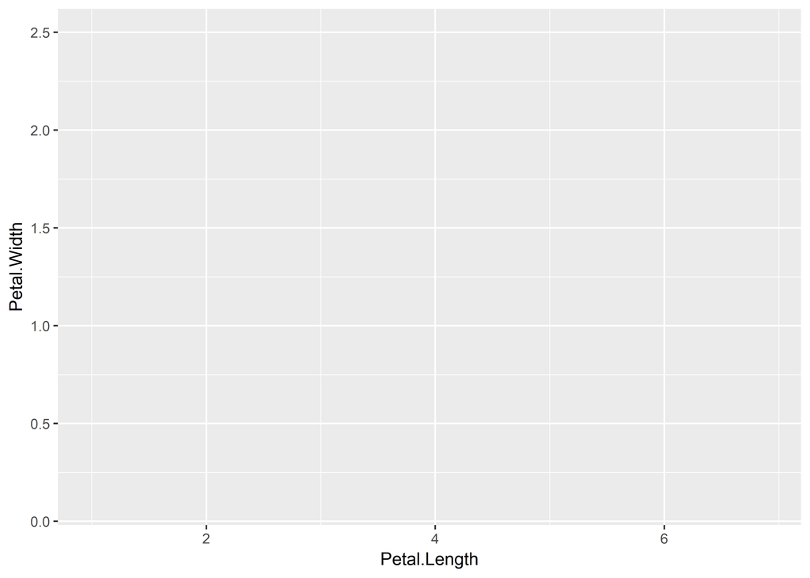

```r
data(iris) # carregando os dados de flores
library(ggplot2)

iris %>%
  ggplot(aes(x = Petal.Length, y = Petal.Width))
```

Agora informamos como queremos marcar visualmente os dados que dissemos pertencerem ao gráfico. Usamos um sinal `+` para isso e para deixar o código mais legível é sempre bom pular uma linha. A maioria dos objetos que usaremos são *geoms*. Para essa visualização, basta usar `geom_point()`.

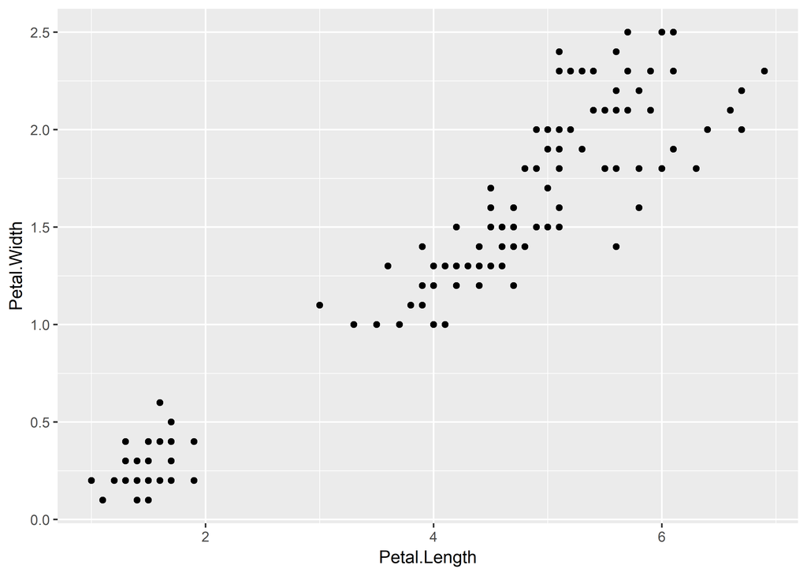

```r
iris %>%
  ggplot(aes(x = Petal.Length, y = Petal.Width)) +
  geom_point()
```

Podemos customizar com certo detalhamento o gráfico.

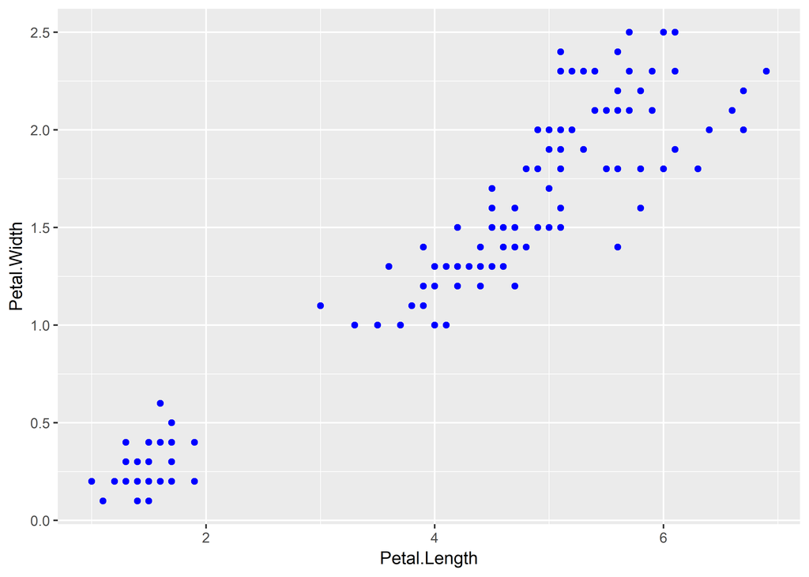

```r
iris %>%
  ggplot(aes(x = Petal.Length, y = Petal.Width)) +
  geom_point(color = "blue")
```

E mais, podemos usar outras variáveis do DataFrame que alimentamos ao gráfico! O `ggplot2` lida muito bem com variáveis que são fatores para esses fins, então se lembre se tornar esse tipo de variável um fator sempre que possível.

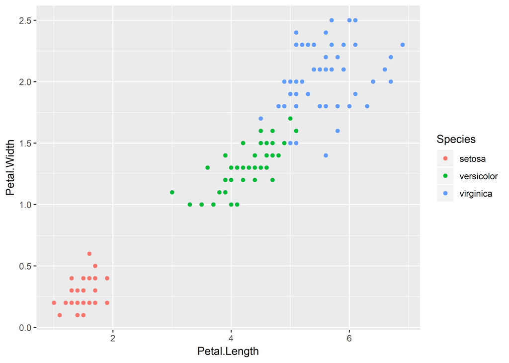

```r
iris %>%
  ggplot(aes(x = Petal.Length, y = Petal.Width, color = Species)) +
  geom_point()
```

Existem outras diferenciações visuais além de cor, como formato e transparência. Usamos para essas atribuições os argumentos `shape=` e `alpha=` respectivamente.

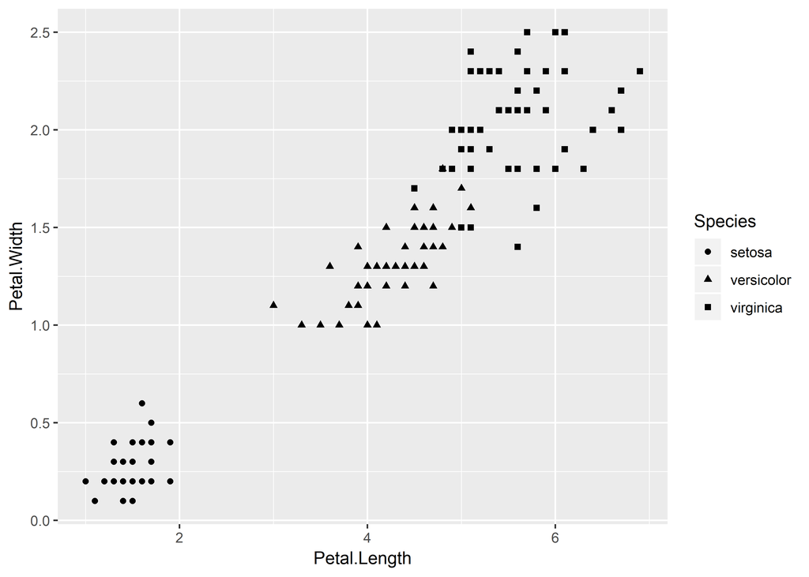

```r
iris %>%
  ggplot(aes(x = Petal.Length, y = Petal.Width, shape = Species)) +
  geom_point()
```

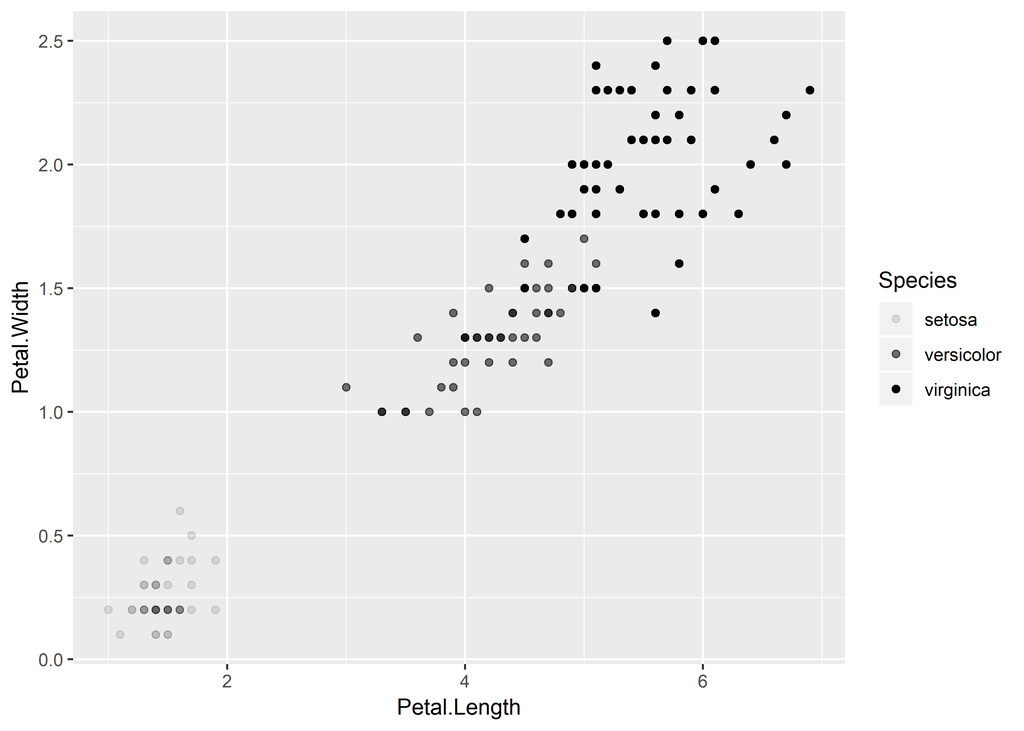

```r
iris %>%
  ggplot(aes(x = Petal.Length, y = Petal.Width, alpha = Species)) +
  geom_point()
```

Via de regra, associar uma variável à transparência é interessante quando a variável é contínua, não discreta.

Note que é possível escrever códigos diferentes que resultem no mesmo gráfico, em particular se você alterar em que função informa a estética do gráfico. Um truque é que normalmente quando serão exibidas várias variáveis é mais interessante informar estética por estética. Quando só uma será exibida, então na primeira estética o eixo vertical pode ser informado sem problemas.

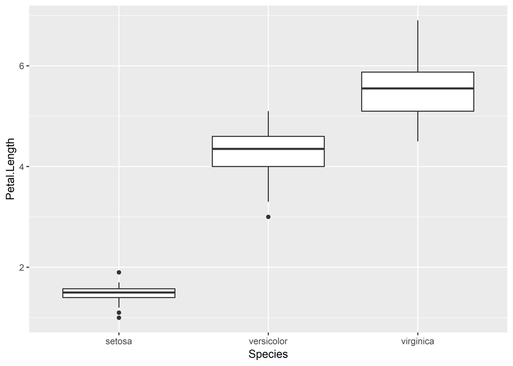

```r
iris %>%
  ggplot(aes(x = Species, y = Petal.Length)) +
  geom_boxplot()
```

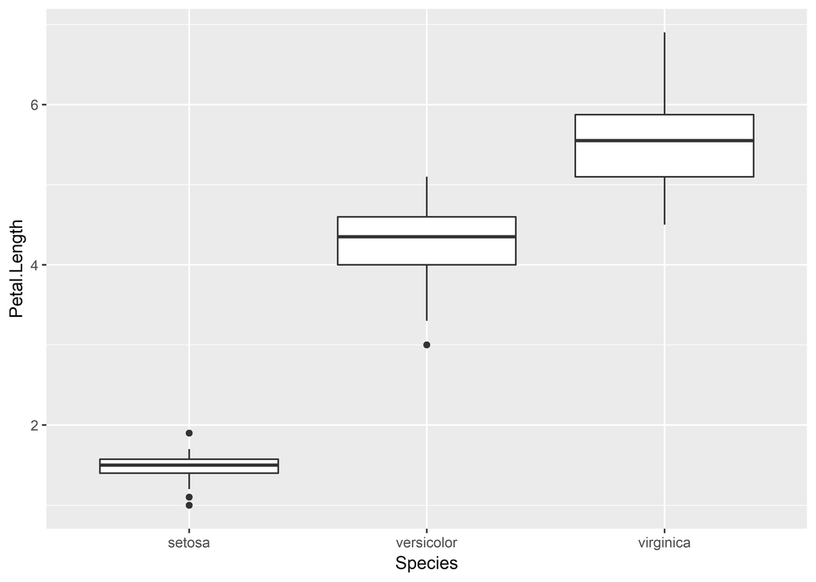

```r
iris %>%
  ggplot(aes(x = Species)) +
  geom_boxplot(aes(y = Petal.Length))
```

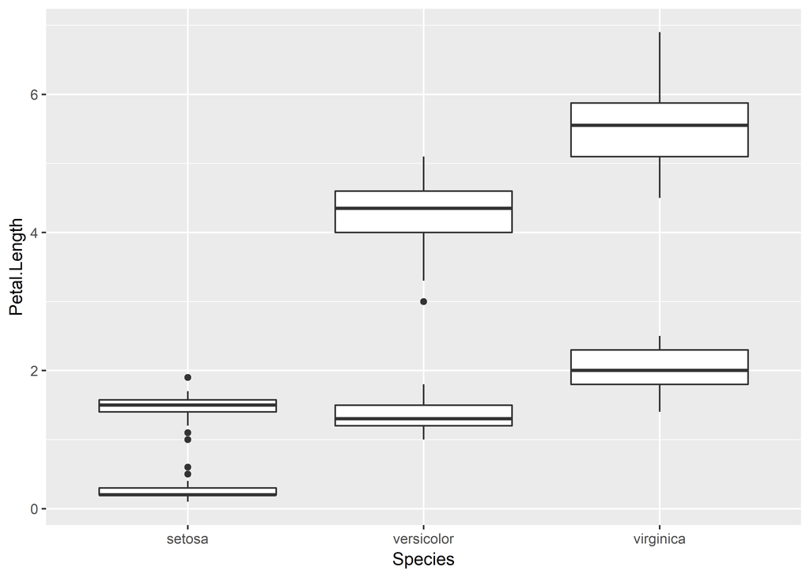

```r
iris %>%
  ggplot(aes(x = Species)) +
  geom_boxplot(aes(y = Petal.Length)) +
  geom_boxplot(aes(y = Petal.Width))
```

Para produzir histogramas, devemos focar em dois argumentos importantes e substitutos, `bins=` e `binwidth=`. Ao definir o primeiro, defini-se uma quantidade fixa de barras do histograma e a largura delas se ajeita. Definindo o segundo, temos um processo contrário.

Escolher um número certo é mais arte que ciência. É sempre recomendado explorar um pouco opções diferentes e evitar tanto histogramas muito “quebrados”, com grandes espaços vazios, quanto histogramas muito “unidos”, que preenchem boa parte do gráfico sem informar muito sobre a distribuição dos dados.

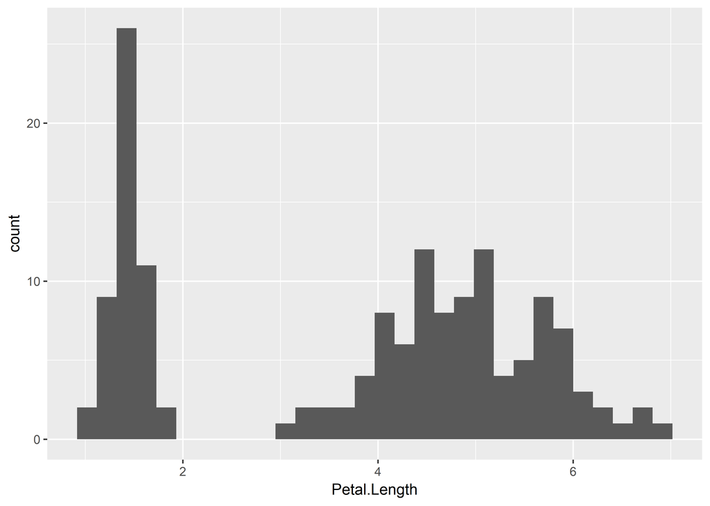

```r
iris %>%
  ggplot(aes(x = Petal.Length)) +
  geom_histogram()
```

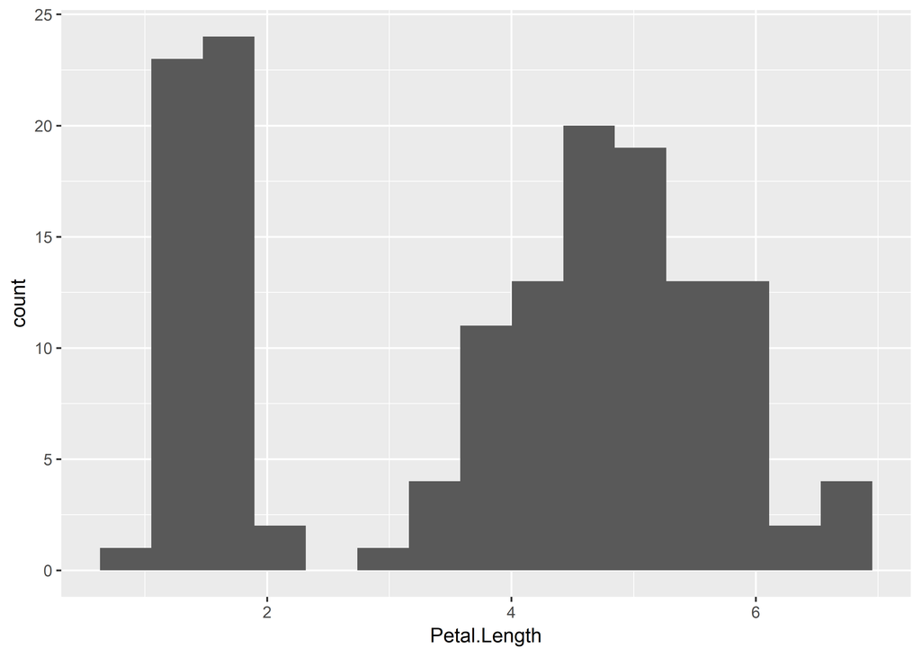

```r
iris %>%
  ggplot(aes(x = Petal.Length)) +
  geom_histogram(bins = 15)
```

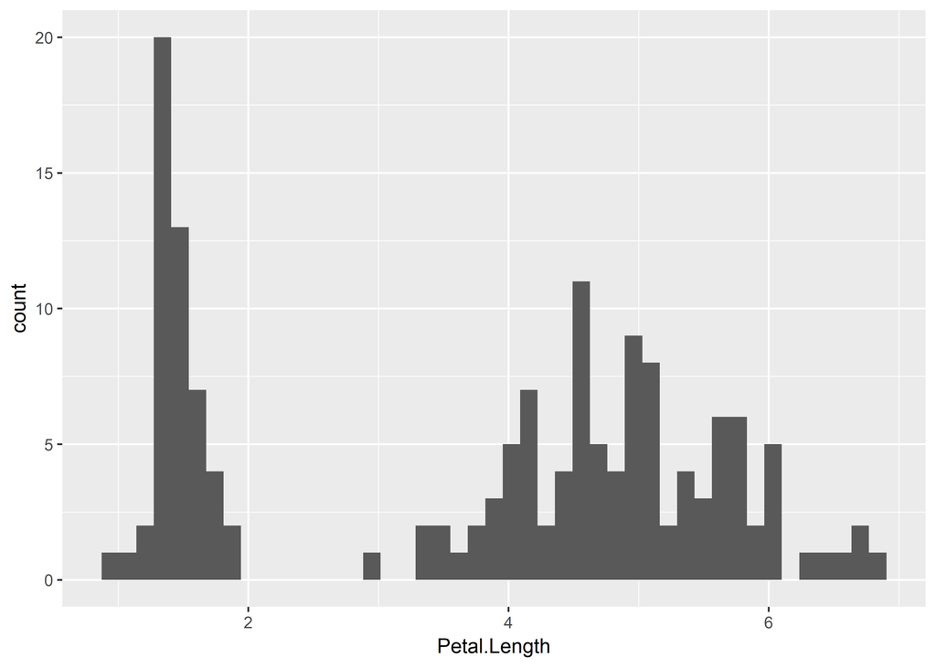

```r
iris %>%
  ggplot(aes(x = Petal.Length)) +
  geom_histogram(bins = 45)
```

Vamos agora expandir um pouco a nossa base de dados e nosso vocabulário com `ggplot2`. `xlab()` e `ylab()` dão as legendas de cada eixo. `labs()` permite títulos para outros objetos como o título do gráfico e legenda, basta especificar em cada argumento apropriado. `title=` para o título, `col=` para a legenda do código de cores do gráfico, `caption=` para a legenda.

Note que gráficos em `ggplot2` são extremamente modulares. Basta adicionar camadas.

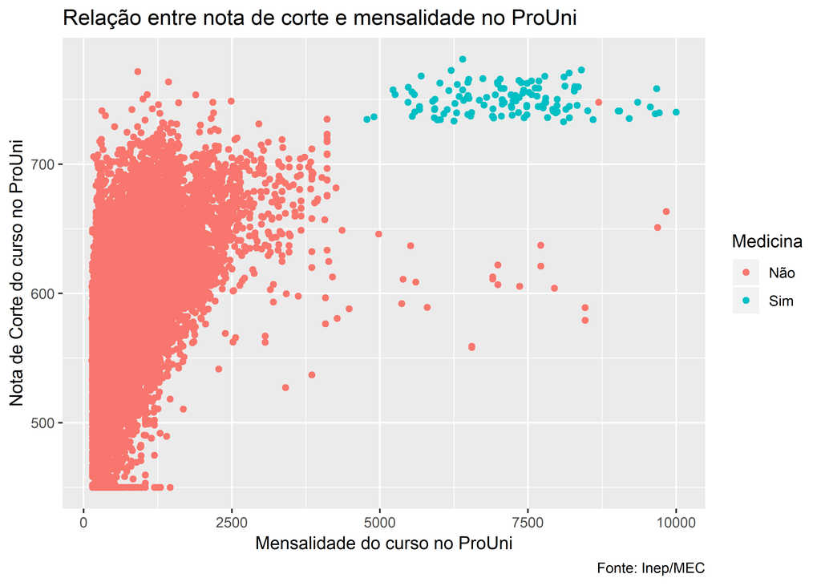

```r
prouni = readRDS("prouni.Rds")

prouni %>%
  ggplot(aes(x = mensalidade, y = nota_integral_ampla,
             color = Medicina, show.legend = FALSE)) +
  geom_point() +
  xlab("Mensalidade do curso no ProUni") +
  ylab("Nota de Corte do curso no ProUni") +
  labs(title = "Relação entre nota de corte e mensalidade no ProUni",
       col = "Medicina",
       caption = "Fonte: Inep/MEC")
```

Uma alternativa ao `geom_point()` é usar o `geom_smooth()` que exibe um polinômio estimado com os dados.

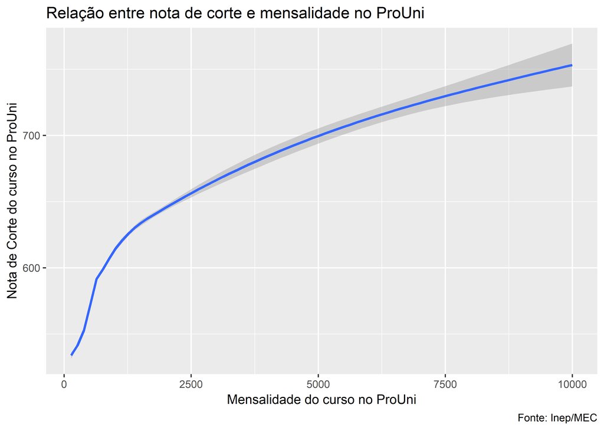

```r
prouni %>%
  ggplot(aes(x = mensalidade, y = nota_integral_ampla)) +
  geom_smooth() +
  xlab("Mensalidade do curso no ProUni") +
  ylab("Nota de Corte do curso no ProUni") +
  labs(title = "Relação entre nota de corte e mensalidade no ProUni",
       caption = "Fonte: Inep/MEC")
```

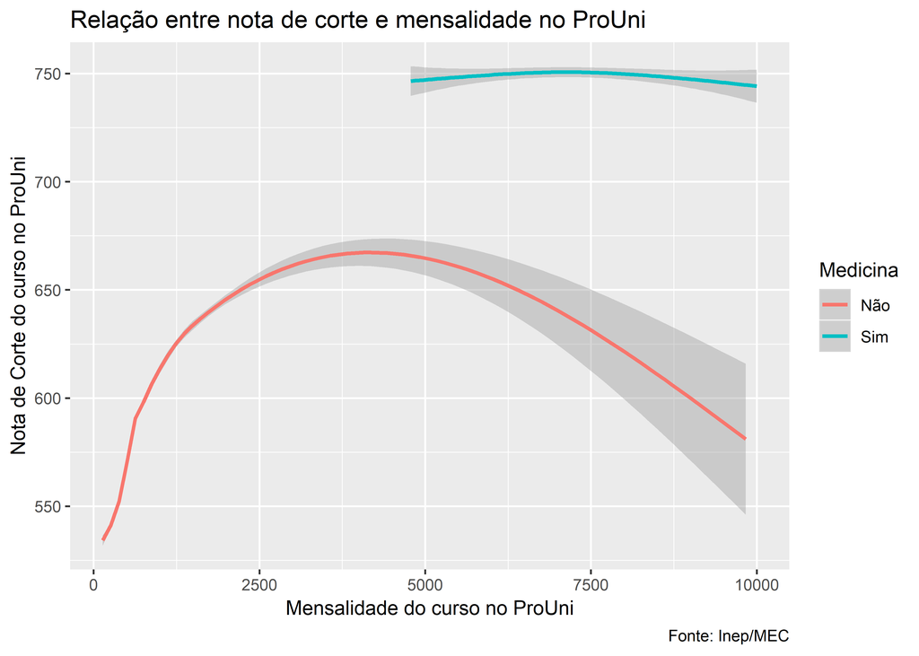

```r
prouni %>%
  ggplot(aes(x = mensalidade, y = nota_integral_ampla,
             color = Medicina, show.legend = FALSE)) +
  geom_smooth() +
  xlab("Mensalidade do curso no ProUni") +
  ylab("Nota de Corte do curso no ProUni") +
  labs(title = "Relação entre nota de corte e mensalidade no ProUni",
       col = "Medicina",
       caption = "Fonte: Inep/MEC")
```

Dois *geoms* razoavelmente comuns não foram cobertos aqui, `geom_bar()` para gráficos de barras e `geom_line()` para gráficos de linhas. Usar esses *geoms* é um procedimento igual ao dos anteriores.

## `ggplot2` e funções estatísticas

O ambiente do `ggplot2` é fantasticamente flexível em boa parte porque todo *geom* tem associado a si um *stat*, alguma função estatística. Por exemplo, por padrão o `geom_histogram()` devolve a contagem dos elementos, mas podemos facilmente fazer ele devolver a densidade dos dados. E mais, podemos usar o `stat_functio()` para plotar a *verdadeira* função de densidade dos dados.

Vamos gerar dados aleatórios e ilustrar isso.

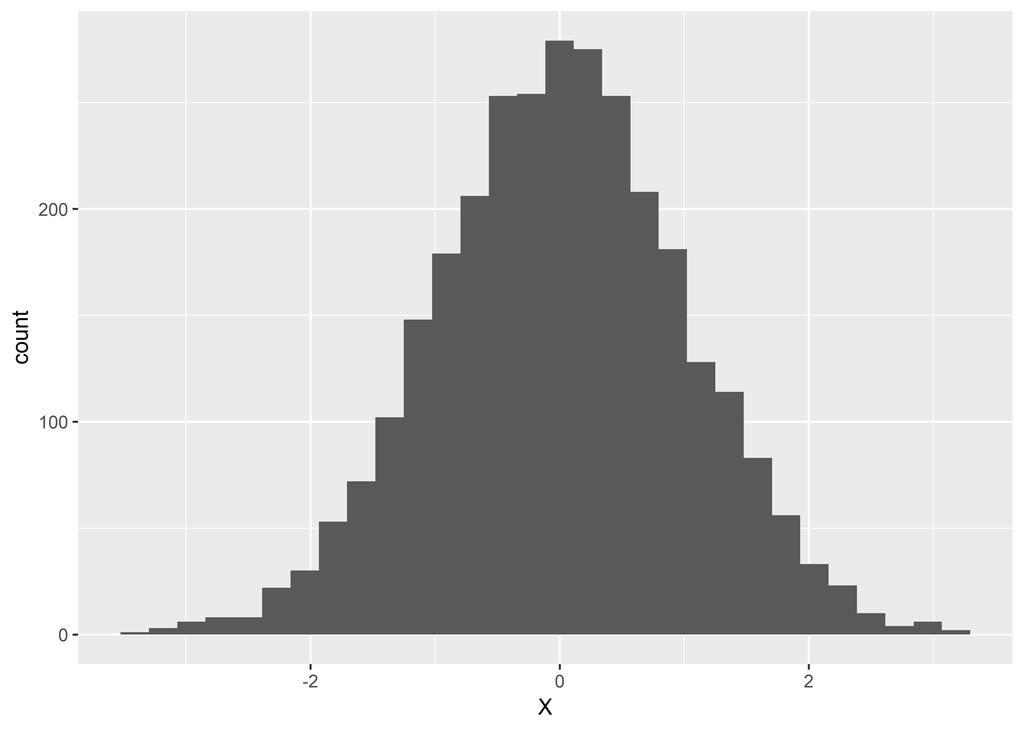

```r
set.seed(1234)

dados = data.frame(X = rnorm(3000)) # dados tem distribuição normal padrão

dados %>%
  ggplot(aes(x = X)) +
  geom_histogram()
```

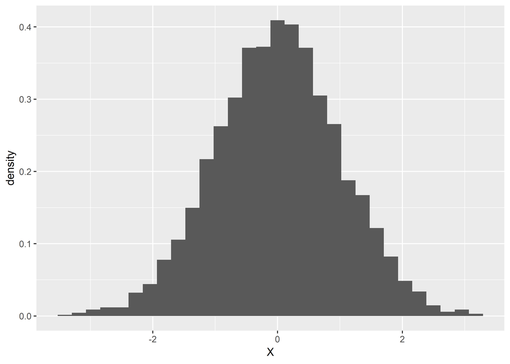

```r
dados %>%
  ggplot(aes(x = X)) +
  geom_histogram(aes(y = ..density..))
```

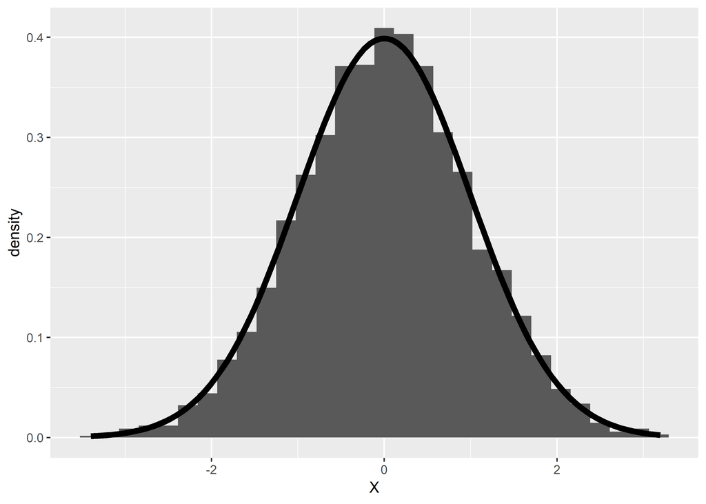

```r
dados %>%
  ggplot(aes(x = X)) +
  geom_histogram(aes(y = ..density..)) +
  stat_function(fun = dnorm, size = 2)
```

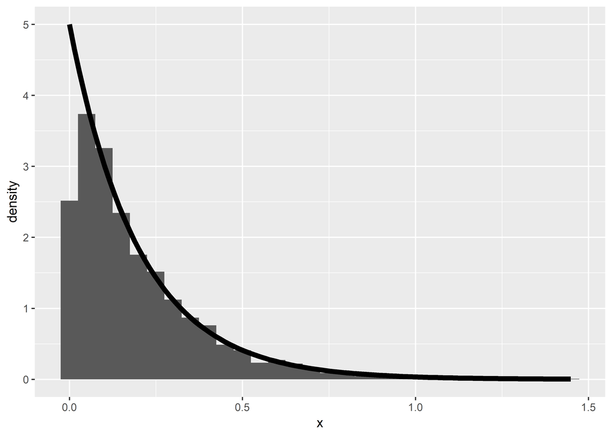

```r
dados2 = data.frame(x = rexp(3000, rate = 5))

dados2 %>%
  ggplot(aes(x = x)) +
  geom_histogram(aes(y = ..density..)) +
  stat_function(fun = dexp,
                args = list(rate = 5),
                size = 2)
```

# Modularidade do `ggplot2`

`ggplot2` é um pacote tão flexível porque implementa uma *gramática* comum a toda e qualquer visualização, por isso existem *dezenas* de extensões ao `ggplot2` para gerar grafos, trabalhar com séries temporais, mapas, dados de radar, animações, árvores evolucionárias, redes e o que quer que venha à mente. A lista completa pode ser encontrada no site oficial do pacote: https://www.ggplot2-exts.org/.

# Exercícios

- Com pipes e funções do `dplyr` encontre a média de mensalidade e de nota de corte para cursos por estado com os dados em `prouni.Rds`
- Abra a base de dados `mtcars`, transforme `cyl` em um fator e faça gráficos de dispersão com variáveis à sua escolha de forma que (i) a cor dos pontos dependa de `cyl` e (ii) a forma dos pontos dependa de `cyl`.
- Ainda com a base `mtcars`, faça um gráfico de dispersão entre `disp` e `hp` de forma que a transparência dos pontos seja uma função de quantas milhas por galão de combustível o carro faz. Leia a documentação da base para descobrir qual variável é.
- Gere 4 gráficos, cada um de amostras com n igual a 100, 1000, 2000 e 5000 de alguma variável aleatória, com um histograma da amostra e a função da densidade da distribuição. Use a biblioteca `gridExtra` para juntar os 4 gráficos em uma visualização só. Essa questão é um pouco mais difícil do que as outras, mas qualquer dúvida que você tenha certamente já foi resolvida no StackOverflow ou está coberta pela documentação do pacote.